# Project: Wrangling and Analyze Data

## Data Gathering

```python
!pip install tweepy
```

```python
import pandas as pd
import numpy as np
import requests
import os
from PIL import Image
from io import BytesIO
import tweepy
import json
pd.set_option('display.max_rows', None)
```

In the cell below, gather **all** three pieces of data for this project and load them in the notebook. **Note:** the methods required to gather each data are different.

1. Directly download the WeRateDogs Twitter archive data (twitter_archive_enhanced.csv)

```python
twitter_arch = pd.read_csv("twitter-archive-enhanced.csv")
#image_prediction = pd.read_csv("image-predictions.tsv" , sep='\t')
```

```python
twitter_arch
```

|  | tweet_id | in_reply_to_status_id | in_reply_to_user_id | timestamp | source | text | retweeted_status_id | retweeted_status_user_id | retweeted_status_timestamp | expanded_urls | rating_numerator | rating_denominator | name | doggo | floofer | pupper | puppo |
| --- | --- | --- | --- | --- | --- | --- | --- | --- | --- | --- | --- | --- | --- | --- | --- | --- | --- |
| 0 | 892420643555336193 | NaN | NaN | 2017-08-01 16:23:56 +0000 | <a href="http://twitter.com/download/iphone" r... | This is Phineas. He's a mystical boy. Only eve... | NaN | NaN | NaN | https://twitter.com/dog_rates/status/892420643... | 13 | 10 | Phineas | None | None | None | None |
| 1 | 892177421306343426 | NaN | NaN | 2017-08-01 00:17:27 +0000 | <a href="http://twitter.com/download/iphone" r... | This is Tilly. She's just checking pup on you.... | NaN | NaN | NaN | https://twitter.com/dog_rates/status/892177421... | 13 | 10 | Tilly | None | None | None | None |
| 2 | 891815181378084864 | NaN | NaN | 2017-07-31 00:18:03 +0000 | <a href="http://twitter.com/download/iphone" r... | This is Archie. He is a rare Norwegian Pouncin... | NaN | NaN | NaN | https://twitter.com/dog_rates/status/891815181... | 12 | 10 | Archie | None | None | None | None |
| 3 | 891689557279858688 | NaN | NaN | 2017-07-30 15:58:51 +0000 | <a href="http://twitter.com/download/iphone" r... | This is Darla. She commenced a snooze mid meal... | NaN | NaN | NaN | https://twitter.com/dog_rates/status/891689557... | 13 | 10 | Darla | None | None | None | None |
| 4 | 891327558926688256 | NaN | NaN | 2017-07-29 16:00:24 +0000 | <a href="http://twitter.com/download/iphone" r... | This is Franklin. He would like you to stop ca... | NaN | NaN | NaN | https://twitter.com/dog_rates/status/891327558... | 12 | 10 | Franklin | None | None | None | None |
| 5 | 891087950875897856 | NaN | NaN | 2017-07-29 00:08:17 +0000 | <a href="http://twitter.com/download/iphone" r... | Here we have a majestic great white breaching ... | NaN | NaN | NaN | https://twitter.com/dog_rates/status/891087950... | 13 | 10 | None | None | None | None | None |
| 6 | 890971913173991426 | NaN | NaN | 2017-07-28 16:27:12 +0000 | <a href="http://twitter.com/download/iphone" r... | Meet Jax. He enjoys ice cream so much he gets ... | NaN | NaN | NaN | https://gofundme.com/ydvmve-surgery-for-jax,ht... | 13 | 10 | Jax | None | None | None | None |
| 7 | 890729181411237888 | NaN | NaN | 2017-07-28 00:22:40 +0000 | <a href="http://twitter.com/download/iphone" r... | When you watch your owner call another dog a g... | NaN | NaN | NaN | https://twitter.com/dog_rates/status/890729181... | 13 | 10 | None | None | None | None | None |
| 8 | 890609185150312448 | NaN | NaN | 2017-07-27 16:25:51 +0000 | <a href="http://twitter.com/download/iphone" r... | This is Zoey. She doesn't want to be one of th... | NaN | NaN | NaN | https://twitter.com/dog_rates/status/890609185... | 13 | 10 | Zoey | None | None | None | None |
| 9 | 890240255349198849 | NaN | NaN | 2017-07-26 15:59:51 +0000 | <a href="http://twitter.com/download/iphone" r... | This is Cassie. She is a college pup. Studying... | NaN | NaN | NaN | https://twitter.com/dog_rates/status/890240255... | 14 | 10 | Cassie | doggo | None | None | None |
| 10 | 890006608113172480 | NaN | NaN | 2017-07-26 00:31:25 +0000 | <a href="http://twitter.com/download/iphone" r... | This is Koda. He is a South Australian decksha... | NaN | NaN | NaN | https://twitter.com/dog_rates/status/890006608... | 13 | 10 | Koda | None | None | None | None |
| 11 | 889880896479866881 | NaN | NaN | 2017-07-25 16:11:53 +0000 | <a href="http://twitter.com/download/iphone" r... | This is Bruno. He is a service shark. Only get... | NaN | NaN | NaN | https://twitter.com/dog_rates/status/889880896... | 13 | 10 | Bruno | None | None | None | None |
| 12 | 889665388333682689 | NaN | NaN | 2017-07-25 01:55:32 +0000 | <a href="http://twitter.com/download/iphone" r... | Here's a puppo that seems to be on the fence a... | NaN | NaN | NaN | https://twitter.com/dog_rates/status/889665388... | 13 | 10 | None | None | None | None | puppo |
| 13 | 889638837579907072 | NaN | NaN | 2017-07-25 00:10:02 +0000 | <a href="http://twitter.com/download/iphone" r... | This is Ted. He does his best. Sometimes that'... | NaN | NaN | NaN | https://twitter.com/dog_rates/status/889638837... | 12 | 10 | Ted | None | None | None | None |
| 14 | 889531135344209921 | NaN | NaN | 2017-07-24 17:02:04 +0000 | <a href="http://twitter.com/download/iphone" r... | This is Stuart. He's sporting his favorite fan... | NaN | NaN | NaN | https://twitter.com/dog_rates/status/889531135... | 13 | 10 | Stuart | None | None | None | puppo |
| 15 | 889278841981685760 | NaN | NaN | 2017-07-24 00:19:32 +0000 | <a href="http://twitter.com/download/iphone" r... | This is Oliver. You're witnessing one of his m... | NaN | NaN | NaN | https://twitter.com/dog_rates/status/889278841... | 13 | 10 | Oliver | None | None | None | None |
| 16 | 888917238123831296 | NaN | NaN | 2017-07-23 00:22:39 +0000 | <a href="http://twitter.com/download/iphone" r... | This is Jim. He found a fren. Taught him how t... | NaN | NaN | NaN | https://twitter.com/dog_rates/status/888917238... | 12 | 10 | Jim | None | None | None | None |
| 17 | 888804989199671297 | NaN | NaN | 2017-07-22 16:56:37 +0000 | <a href="http://twitter.com/download/iphone" r... | This is Zeke. He has a new stick. Very proud o... | NaN | NaN | NaN | https://twitter.com/dog_rates/status/888804989... | 13 | 10 | Zeke | None | None | None | None |
| 18 | 888554962724278272 | NaN | NaN | 2017-07-22 00:23:06 +0000 | <a href="http://twitter.com/download/iphone" r... | This is Ralphus. He's powering up. Attempting ... | NaN | NaN | NaN | https://twitter.com/dog_rates/status/888554962... | 13 | 10 | Ralphus | None | None | None | None |
| 19 | 888202515573088257 | NaN | NaN | 2017-07-21 01:02:36 +0000 | <a href="http://twitter.com/download/iphone" r... | RT @dog_rates: This is Canela. She attempted s... | 8.874740e+17 | 4.196984e+09 | 2017-07-19 00:47:34 +0000 | https://twitter.com/dog_rates/status/887473957... | 13 | 10 | Canela | None | None | None | None |
| 20 | 888078434458587136 | NaN | NaN | 2017-07-20 16:49:33 +0000 | <a href="http://twitter.com/download/iphone" r... | This is Gerald. He was just told he didn't get... | NaN | NaN | NaN | https://twitter.com/dog_rates/status/888078434... | 12 | 10 | Gerald | None | None | None | None |
| 21 | 887705289381826560 | NaN | NaN | 2017-07-19 16:06:48 +0000 | <a href="http://twitter.com/download/iphone" r... | This is Jeffrey. He has a monopoly on the pool... | NaN | NaN | NaN | https://twitter.com/dog_rates/status/887705289... | 13 | 10 | Jeffrey | None | None | None | None |
| 22 | 887517139158093824 | NaN | NaN | 2017-07-19 03:39:09 +0000 | <a href="http://twitter.com/download/iphone" r... | I've yet to rate a Venezuelan Hover Wiener. Th... | NaN | NaN | NaN | https://twitter.com/dog_rates/status/887517139... | 14 | 10 | such | None | None | None | None |
| 23 | 887473957103951883 | NaN | NaN | 2017-07-19 00:47:34 +0000 | <a href="http://twitter.com/download/iphone" r... | This is Canela. She attempted some fancy porch... | NaN | NaN | NaN | https://twitter.com/dog_rates/status/887473957... | 13 | 10 | Canela | None | None | None | None |
| 24 | 887343217045368832 | NaN | NaN | 2017-07-18 16:08:03 +0000 | <a href="http://twitter.com/download/iphone" r... | You may not have known you needed to see this ... | NaN | NaN | NaN | https://twitter.com/dog_rates/status/887343217... | 13 | 10 | None | None | None | None | None |
| 25 | 887101392804085760 | NaN | NaN | 2017-07-18 00:07:08 +0000 | <a href="http://twitter.com/download/iphone" r... | This... is a Jubilant Antarctic House Bear. We... | NaN | NaN | NaN | https://twitter.com/dog_rates/status/887101392... | 12 | 10 | None | None | None | None | None |
| 26 | 886983233522544640 | NaN | NaN | 2017-07-17 16:17:36 +0000 | <a href="http://twitter.com/download/iphone" r... | This is Maya. She's very shy. Rarely leaves he... | NaN | NaN | NaN | https://twitter.com/dog_rates/status/886983233... | 13 | 10 | Maya | None | None | None | None |
| 27 | 886736880519319552 | NaN | NaN | 2017-07-16 23:58:41 +0000 | <a href="http://twitter.com/download/iphone" r... | This is Mingus. He's a wonderful father to his... | NaN | NaN | NaN | https://www.gofundme.com/mingusneedsus,https:/... | 13 | 10 | Mingus | None | None | None | None |
| 28 | 886680336477933568 | NaN | NaN | 2017-07-16 20:14:00 +0000 | <a href="http://twitter.com/download/iphone" r... | This is Derek. He's late for a dog meeting. 13... | NaN | NaN | NaN | https://twitter.com/dog_rates/status/886680336... | 13 | 10 | Derek | None | None | None | None |
| 29 | 886366144734445568 | NaN | NaN | 2017-07-15 23:25:31 +0000 | <a href="http://twitter.com/download/iphone" r... | This is Roscoe. Another pupper fallen victim t... | NaN | NaN | NaN | https://twitter.com/dog_rates/status/886366144... | 12 | 10 | Roscoe | None | None | pupper | None |

[output cut: 2326 more lines]

1. Use the Requests library to download the tweet image prediction (image_predictions.tsv)

```python
#URL of the file
url = 'https://d17h27t6h515a5.cloudfront.net/topher/2017/August/599fd2ad_image-predictions/image-predictions.tsv'

# get file with the image predictions
with open('image-predictions.tsv' , 'wb') as file:
    predictions = requests.get(url)
    file.write(predictions.content)

# load image predictions
image_prediction = pd.read_csv('image-predictions.tsv', sep = '\t')
```

```python
image_prediction
```

|  | tweet_id | jpg_url | img_num | p1 | p1_conf | p1_dog | p2 | p2_conf | p2_dog | p3 | p3_conf | p3_dog |
| --- | --- | --- | --- | --- | --- | --- | --- | --- | --- | --- | --- | --- |
| 0 | 666020888022790149 | https://pbs.twimg.com/media/CT4udn0WwAA0aMy.jpg | 1 | Welsh_springer_spaniel | 0.465074 | True | collie | 1.566650e-01 | True | Shetland_sheepdog | 6.142850e-02 | True |
| 1 | 666029285002620928 | https://pbs.twimg.com/media/CT42GRgUYAA5iDo.jpg | 1 | redbone | 0.506826 | True | miniature_pinscher | 7.419170e-02 | True | Rhodesian_ridgeback | 7.201000e-02 | True |
| 2 | 666033412701032449 | https://pbs.twimg.com/media/CT4521TWwAEvMyu.jpg | 1 | German_shepherd | 0.596461 | True | malinois | 1.385840e-01 | True | bloodhound | 1.161970e-01 | True |
| 3 | 666044226329800704 | https://pbs.twimg.com/media/CT5Dr8HUEAA-lEu.jpg | 1 | Rhodesian_ridgeback | 0.408143 | True | redbone | 3.606870e-01 | True | miniature_pinscher | 2.227520e-01 | True |
| 4 | 666049248165822465 | https://pbs.twimg.com/media/CT5IQmsXIAAKY4A.jpg | 1 | miniature_pinscher | 0.560311 | True | Rottweiler | 2.436820e-01 | True | Doberman | 1.546290e-01 | True |
| 5 | 666050758794694657 | https://pbs.twimg.com/media/CT5Jof1WUAEuVxN.jpg | 1 | Bernese_mountain_dog | 0.651137 | True | English_springer | 2.637880e-01 | True | Greater_Swiss_Mountain_dog | 1.619920e-02 | True |
| 6 | 666051853826850816 | https://pbs.twimg.com/media/CT5KoJ1WoAAJash.jpg | 1 | box_turtle | 0.933012 | False | mud_turtle | 4.588540e-02 | False | terrapin | 1.788530e-02 | False |
| 7 | 666055525042405380 | https://pbs.twimg.com/media/CT5N9tpXIAAifs1.jpg | 1 | chow | 0.692517 | True | Tibetan_mastiff | 5.827940e-02 | True | fur_coat | 5.444860e-02 | False |
| 8 | 666057090499244032 | https://pbs.twimg.com/media/CT5PY90WoAAQGLo.jpg | 1 | shopping_cart | 0.962465 | False | shopping_basket | 1.459380e-02 | False | golden_retriever | 7.958960e-03 | True |
| 9 | 666058600524156928 | https://pbs.twimg.com/media/CT5Qw94XAAA_2dP.jpg | 1 | miniature_poodle | 0.201493 | True | komondor | 1.923050e-01 | True | soft-coated_wheaten_terrier | 8.208610e-02 | True |
| 10 | 666063827256086533 | https://pbs.twimg.com/media/CT5Vg_wXIAAXfnj.jpg | 1 | golden_retriever | 0.775930 | True | Tibetan_mastiff | 9.371780e-02 | True | Labrador_retriever | 7.242660e-02 | True |
| 11 | 666071193221509120 | https://pbs.twimg.com/media/CT5cN_3WEAAlOoZ.jpg | 1 | Gordon_setter | 0.503672 | True | Yorkshire_terrier | 1.742010e-01 | True | Pekinese | 1.094540e-01 | True |
| 12 | 666073100786774016 | https://pbs.twimg.com/media/CT5d9DZXAAALcwe.jpg | 1 | Walker_hound | 0.260857 | True | English_foxhound | 1.753820e-01 | True | Ibizan_hound | 9.747050e-02 | True |
| 13 | 666082916733198337 | https://pbs.twimg.com/media/CT5m4VGWEAAtKc8.jpg | 1 | pug | 0.489814 | True | bull_mastiff | 4.047220e-01 | True | French_bulldog | 4.895950e-02 | True |
| 14 | 666094000022159362 | https://pbs.twimg.com/media/CT5w9gUW4AAsBNN.jpg | 1 | bloodhound | 0.195217 | True | German_shepherd | 7.825980e-02 | True | malinois | 7.562780e-02 | True |
| 15 | 666099513787052032 | https://pbs.twimg.com/media/CT51-JJUEAA6hV8.jpg | 1 | Lhasa | 0.582330 | True | Shih-Tzu | 1.661920e-01 | True | Dandie_Dinmont | 8.968830e-02 | True |
| 16 | 666102155909144576 | https://pbs.twimg.com/media/CT54YGiWUAEZnoK.jpg | 1 | English_setter | 0.298617 | True | Newfoundland | 1.498420e-01 | True | borzoi | 1.336490e-01 | True |
| 17 | 666104133288665088 | https://pbs.twimg.com/media/CT56LSZWoAAlJj2.jpg | 1 | hen | 0.965932 | False | cock | 3.391940e-02 | False | partridge | 5.206580e-05 | False |
| 18 | 666268910803644416 | https://pbs.twimg.com/media/CT8QCd1WEAADXws.jpg | 1 | desktop_computer | 0.086502 | False | desk | 8.554740e-02 | False | bookcase | 7.947970e-02 | False |
| 19 | 666273097616637952 | https://pbs.twimg.com/media/CT8T1mtUwAA3aqm.jpg | 1 | Italian_greyhound | 0.176053 | True | toy_terrier | 1.118840e-01 | True | basenji | 1.111520e-01 | True |
| 20 | 666287406224695296 | https://pbs.twimg.com/media/CT8g3BpUEAAuFjg.jpg | 1 | Maltese_dog | 0.857531 | True | toy_poodle | 6.306380e-02 | True | miniature_poodle | 2.558060e-02 | True |
| 21 | 666293911632134144 | https://pbs.twimg.com/media/CT8mx7KW4AEQu8N.jpg | 1 | three-toed_sloth | 0.914671 | False | otter | 1.525000e-02 | False | great_grey_owl | 1.320720e-02 | False |
| 22 | 666337882303524864 | https://pbs.twimg.com/media/CT9OwFIWEAMuRje.jpg | 1 | ox | 0.416669 | False | Newfoundland | 2.784070e-01 | True | groenendael | 1.026430e-01 | True |
| 23 | 666345417576210432 | https://pbs.twimg.com/media/CT9Vn7PWoAA_ZCM.jpg | 1 | golden_retriever | 0.858744 | True | Chesapeake_Bay_retriever | 5.478680e-02 | True | Labrador_retriever | 1.424090e-02 | True |
| 24 | 666353288456101888 | https://pbs.twimg.com/media/CT9cx0tUEAAhNN_.jpg | 1 | malamute | 0.336874 | True | Siberian_husky | 1.476550e-01 | True | Eskimo_dog | 9.341240e-02 | True |
| 25 | 666362758909284353 | https://pbs.twimg.com/media/CT9lXGsUcAAyUFt.jpg | 1 | guinea_pig | 0.996496 | False | skunk | 2.402450e-03 | False | hamster | 4.608630e-04 | False |
| 26 | 666373753744588802 | https://pbs.twimg.com/media/CT9vZEYWUAAlZ05.jpg | 1 | soft-coated_wheaten_terrier | 0.326467 | True | Afghan_hound | 2.595510e-01 | True | briard | 2.068030e-01 | True |
| 27 | 666396247373291520 | https://pbs.twimg.com/media/CT-D2ZHWIAA3gK1.jpg | 1 | Chihuahua | 0.978108 | True | toy_terrier | 9.396970e-03 | True | papillon | 4.576810e-03 | True |
| 28 | 666407126856765440 | https://pbs.twimg.com/media/CT-NvwmW4AAugGZ.jpg | 1 | black-and-tan_coonhound | 0.529139 | True | bloodhound | 2.442200e-01 | True | flat-coated_retriever | 1.738100e-01 | True |
| 29 | 666411507551481857 | https://pbs.twimg.com/media/CT-RugiWIAELEaq.jpg | 1 | coho | 0.404640 | False | barracouta | 2.714850e-01 | False | gar | 1.899450e-01 | False |

[output cut: 2045 more lines]

```python
#image_prediction
```

1. Use the Tweepy library to query additional data via the Twitter API (tweet_json.txt)

```python
f = open("tweet-json.txt", "r")
print(f.read())
```

[output not shown]

```python
llist=[]
with open("tweet-json.txt") as file:
     for line in file:
        llist.append(line)
```

```python
count_df = pd.DataFrame(columns = ["tweet_id","retweet_count","favorite_count"] )
```

```python
for i in llist:
    data = i
    load_data = json.loads(data)
    count_df = count_df.append({"tweet_id": load_data["id"] ,
                                "retweet_count": load_data["retweet_count"],
                                "favorite_count": load_data["favorite_count"]
                               },ignore_index=True)
```

```python
count_df
```

|  | tweet_id | retweet_count | favorite_count |
| --- | --- | --- | --- |
| 0 | 892420643555336193 | 8853 | 39467 |
| 1 | 892177421306343426 | 6514 | 33819 |
| 2 | 891815181378084864 | 4328 | 25461 |
| 3 | 891689557279858688 | 8964 | 42908 |
| 4 | 891327558926688256 | 9774 | 41048 |
| 5 | 891087950875897856 | 3261 | 20562 |
| 6 | 890971913173991426 | 2158 | 12041 |
| 7 | 890729181411237888 | 16716 | 56848 |
| 8 | 890609185150312448 | 4429 | 28226 |
| 9 | 890240255349198849 | 7711 | 32467 |
| 10 | 890006608113172480 | 7624 | 31166 |
| 11 | 889880896479866881 | 5156 | 28268 |
| 12 | 889665388333682689 | 8538 | 38818 |
| 13 | 889638837579907072 | 4735 | 27672 |
| 14 | 889531135344209921 | 2321 | 15359 |
| 15 | 889278841981685760 | 5637 | 25652 |
| 16 | 888917238123831296 | 4709 | 29611 |
| 17 | 888804989199671297 | 4559 | 26080 |
| 18 | 888554962724278272 | 3732 | 20290 |
| 19 | 888078434458587136 | 3653 | 22201 |
| 20 | 887705289381826560 | 5609 | 30779 |
| 21 | 887517139158093824 | 12082 | 46959 |
| 22 | 887473957103951883 | 18781 | 69871 |
| 23 | 887343217045368832 | 10737 | 34222 |
| 24 | 887101392804085760 | 6167 | 31061 |
| 25 | 886983233522544640 | 8084 | 35859 |
| 26 | 886736880519319552 | 3443 | 12306 |
| 27 | 886680336477933568 | 4610 | 22798 |
| 28 | 886366144734445568 | 3316 | 21524 |
| 29 | 886267009285017600 | 4 | 117 |

[output cut: 2324 more lines]

# Assessing Data

In this section, detect and document at least **eight (8) quality issues and two (2) tidiness issue**. You must use **both** visual assessment programmatic assessement to assess the data.

**Note:** pay attention to the following key points when you access the data.

- You only want original ratings (no retweets) that have images. Though there are 5000+ tweets in the dataset, not all are dog ratings and some are retweets.
- Assessing and cleaning the entire dataset completely would require a lot of time, and is not necessary to practice and demonstrate your skills in data wrangling. Therefore, the requirements of this project are only to assess and clean at least 8 quality issues and at least 2 tidiness issues in this dataset.
- The fact that the rating numerators are greater than the denominators does not need to be cleaned. This [unique rating system](http://knowyourmeme.com/memes/theyre-good-dogs-brent) is a big part of the popularity of WeRateDogs.
- You do not need to gather the tweets beyond August 1st, 2017. You can, but note that you won't be able to gather the image predictions for these tweets since you don't have access to the algorithm used.

```python
twitter_arch.info()
```

```
<class 'pandas.core.frame.DataFrame'>
RangeIndex: 2356 entries, 0 to 2355
Data columns (total 17 columns):
 #   Column                      Non-Null Count  Dtype
---  ------                      --------------  -----
 0   tweet_id                    2356 non-null   int64
 1   in_reply_to_status_id       78 non-null     float64
 2   in_reply_to_user_id         78 non-null     float64
 3   timestamp                   2356 non-null   object
 4   source                      2356 non-null   object
 5   text                        2356 non-null   object
 6   retweeted_status_id         181 non-null    float64
 7   retweeted_status_user_id    181 non-null    float64
 8   retweeted_status_timestamp  181 non-null    object
 9   expanded_urls               2297 non-null   object
 10  rating_numerator            2356 non-null   int64
 11  rating_denominator          2356 non-null   int64
 12  name                        2356 non-null   object
 13  doggo                       2356 non-null   object
 14  floofer                     2356 non-null   object
 15  pupper                      2356 non-null   object
 16  puppo                       2356 non-null   object
dtypes: float64(4), int64(3), object(10)
memory usage: 313.0+ KB
```

```python
list_twt = twitter_arch.columns

for i in list_twt:
    print("\n--------------------------------")
    print("column : " , i)
    print("type : ", twitter_arch[i].dtypes)
    dup = [1 for j in twitter_arch[i].duplicated() if j==True]
    print("duplicates : ", len(dup))
    print(twitter_arch[i].unique())
```

```
--------------------------------
column :  tweet_id
type :  int64
duplicates :  0
[892420643555336193 892177421306343426 891815181378084864 ...
 666033412701032449 666029285002620928 666020888022790149]

--------------------------------
column :  in_reply_to_status_id
type :  float64
duplicates :  2278
[           nan 8.86266357e+17 8.81607037e+17 8.79553827e+17
 8.70726203e+17 8.63425646e+17 6.67152164e+17 8.57156678e+17
 8.55818117e+17 8.56286004e+17 8.55861584e+17 8.55858536e+17
 8.50328819e+17 8.48212112e+17 8.47606176e+17 7.59099524e+17
 8.40698300e+17 8.38145499e+17 8.38085539e+17 8.35245984e+17
 8.32087548e+17 8.31903044e+17 8.26598365e+17 8.23326389e+17
 8.21152593e+17 8.13127252e+17 8.11627233e+17 7.33109485e+17
 8.01854331e+17 8.00857954e+17 7.97123751e+17 7.72743019e+17
 7.66711819e+17 7.63865175e+17 7.50180499e+17 7.47648654e+17
 7.46885919e+17 6.91416866e+17 7.38411920e+17 7.29113531e+17
 7.07980066e+17 7.03255936e+17 7.04485745e+17 7.03041950e+17
 6.96488711e+17 6.75349384e+17 6.70668383e+17 6.93642232e+17
 6.93572216e+17 6.92417313e+17 6.92041935e+17 6.90341254e+17
 6.86034025e+17 6.85547936e+17 6.84959799e+17 6.84481075e+17
 6.84222868e+17 6.82788442e+17 6.81339449e+17 6.78021116e+17
 6.76588346e+17 6.75707330e+17 6.75845657e+17 6.75497103e+17
 6.74999808e+17 6.74793399e+17 6.71729907e+17 6.74752233e+17
 6.74739953e+17 6.74468881e+17 6.65814697e+17 6.73715862e+17
 6.71561002e+17 6.71544874e+17 6.69354383e+17 6.67806455e+17
 6.68920717e+17 6.67065536e+17]

--------------------------------
column :  in_reply_to_user_id
type :  float64
duplicates :  2324
[           nan 2.28118160e+09 4.73844300e+07 3.10544075e+09
 1.64877600e+07 7.75962000e+07 4.19698384e+09 1.80670967e+08
 2.79280991e+08 1.94351775e+08 1.36157220e+07 2.19550580e+07
 8.40547864e+17 2.89413118e+09 2.62595760e+07 3.05820820e+07
```

[output cut: 348 more lines]

```
type :  object
duplicates :  2354
['None' 'floofer']

--------------------------------
column :  pupper
type :  object
duplicates :  2354
['None' 'pupper']

--------------------------------
column :  puppo
type :  object
duplicates :  2354
['None' 'puppo']
```

```python
len(twitter_arch["source"].unique())
```

```
4
```

```python
twitter_arch["tweet_id"].duplicated().sum()
```

```
0
```

```python
image_prediction.info()
```

```
<class 'pandas.core.frame.DataFrame'>
RangeIndex: 2075 entries, 0 to 2074
Data columns (total 12 columns):
 #   Column    Non-Null Count  Dtype
---  ------    --------------  -----
 0   tweet_id  2075 non-null   int64
 1   jpg_url   2075 non-null   object
 2   img_num   2075 non-null   int64
 3   p1        2075 non-null   object
 4   p1_conf   2075 non-null   float64
 5   p1_dog    2075 non-null   bool
 6   p2        2075 non-null   object
 7   p2_conf   2075 non-null   float64
 8   p2_dog    2075 non-null   bool
 9   p3        2075 non-null   object
 10  p3_conf   2075 non-null   float64
 11  p3_dog    2075 non-null   bool
dtypes: bool(3), float64(3), int64(2), object(4)
memory usage: 152.1+ KB
```

```python
list_image = image_prediction.columns

for i in list_image:
    print("\n--------------------------------")
    print("column : " , i)
    print("type : ", image_prediction[i].dtypes)
    dup = [1 for j in image_prediction[i].duplicated() if j==True]
    print("duplicates : ", len(dup))
    print(image_prediction[i].unique())
```

```
--------------------------------
column :  tweet_id
type :  int64
duplicates :  0
[666020888022790149 666029285002620928 666033412701032449 ...
 891815181378084864 892177421306343426 892420643555336193]

--------------------------------
column :  jpg_url
type :  object
duplicates :  66
['https://pbs.twimg.com/media/CT4udn0WwAA0aMy.jpg'
 'https://pbs.twimg.com/media/CT42GRgUYAA5iDo.jpg'
 'https://pbs.twimg.com/media/CT4521TWwAEvMyu.jpg' ...
 'https://pbs.twimg.com/media/DGBdLU1WsAANxJ9.jpg'
 'https://pbs.twimg.com/media/DGGmoV4XsAAUL6n.jpg'
 'https://pbs.twimg.com/media/DGKD1-bXoAAIAUK.jpg']

--------------------------------
column :  img_num
type :  int64
duplicates :  2071
[1 4 2 3]

--------------------------------
column :  p1
type :  object
duplicates :  1697
['Welsh_springer_spaniel' 'redbone' 'German_shepherd'
 'Rhodesian_ridgeback' 'miniature_pinscher' 'Bernese_mountain_dog'
 'box_turtle' 'chow' 'shopping_cart' 'miniature_poodle' 'golden_retriever'
 'Gordon_setter' 'Walker_hound' 'pug' 'bloodhound' 'Lhasa'
 'English_setter' 'hen' 'desktop_computer' 'Italian_greyhound'
 'Maltese_dog' 'three-toed_sloth' 'ox' 'malamute' 'guinea_pig'
 'soft-coated_wheaten_terrier' 'Chihuahua' 'black-and-tan_coonhound'
 'coho' 'toy_terrier' 'Blenheim_spaniel' 'Pembroke' 'llama'
 'Chesapeake_Bay_retriever' 'curly-coated_retriever' 'dalmatian'
 'Ibizan_hound' 'Border_collie' 'Labrador_retriever' 'seat_belt' 'snail'
 'miniature_schnauzer' 'Airedale' 'triceratops' 'swab' 'hay' 'hyena'
 'jigsaw_puzzle' 'West_Highland_white_terrier' 'toy_poodle'
```

[output cut: 248 more lines]

```
 'coffeepot' 'printer' 'otter' 'restaurant' 'bonnet' 'crossword_puzzle'
 'go-kart' 'Sussex_spaniel' 'orangutan' 'canoe' 'barber_chair'
 'traffic_light' 'ibex' 'can_opener' 'Indian_elephant' 'spatula' 'banana']

--------------------------------
column :  p3_conf
type :  float64
duplicates :  69
[0.0614285 0.07201   0.116197  ... 0.0313789 0.0689569 0.07611  ]

--------------------------------
column :  p3_dog
type :  bool
duplicates :  2073
[ True False]
```

```python
count_df.info()
```

```
<class 'pandas.core.frame.DataFrame'>
RangeIndex: 2354 entries, 0 to 2353
Data columns (total 3 columns):
 #   Column          Non-Null Count  Dtype
---  ------          --------------  -----
 0   tweet_id        2354 non-null   object
 1   retweet_count   2354 non-null   object
 2   favorite_count  2354 non-null   object
dtypes: object(3)
memory usage: 55.3+ KB
```

```python
count_df.describe()
```

|  | tweet_id | retweet_count | favorite_count |
| --- | --- | --- | --- |
| count | 2354 | 2354 | 2354 |
| unique | 2354 | 1724 | 2007 |
| top | 892420643555336193 | 1972 | 0 |
| freq | 1 | 5 | 179 |

### Quality issues

1. converting ( retweet_count , favorite_count ) in count_df table from "object" to "int".
2. the ( timestamp ) column in twitter_arch table should be converted to "dateTime" instead of "object".
3. the ( rating_denominator ) values in table twitter_arch should be all converted to 10.
4. the ( rating_numerator ) should be greater than 10. any number less than or equal to 10 will be converted to 11.
5. remove rows that are considered as "retweet" or "reply" since they are not real tweets.
6. drop ( in_reply_to_status_id , in_reply_to_user_id , retweeted_status_id , retweeted_status_user_id , retweeted_status_timestamp ) in twitter_arch table sense there are a lot of missing values.
7. delete unnecessary information from "source" column in twitter_arch table ( for example: converting from'[Vine - Make a Scene](http://vine.co)' ---> "Vine - Make a Scene" ).
8. fixing some dogs name ( for example: "None" , "a" , "O").
9. drop "jpg_url" column in image_prediction table.
10. convert ( tweet_id ) in image_prediction and twitter_arch tables from "int" to "str"/"object".

### Tidiness issues

1. converting "doggo" , "floofer" , "pupper" , and "puppo" columns from twitter_arch table into one column.
2. adding the three datasets together using tweet_id.

## Cleaning Data

In this section, clean **all** of the issues you documented while assessing.

**Note:** Make a copy of the original data before cleaning. Cleaning includes merging individual pieces of data according to the rules of [tidy data](https://cran.r-project.org/web/packages/tidyr/vignettes/tidy-data.html). The result should be a high-quality and tidy master pandas DataFrame (or DataFrames, if appropriate).

```python
# Make copies of original pieces of data

twitter_arch_copy = twitter_arch.copy()
image_prediction_copy = image_prediction.copy()
count_df_copy = count_df.copy()
```

## Quality issue:

### Issue #1:

#### Define: converting ( retweet_count , favorite_count ) in count_df table from "object" to "int".

#### Code

```python
count_df_copy.info()
```

```
<class 'pandas.core.frame.DataFrame'>
RangeIndex: 2354 entries, 0 to 2353
Data columns (total 3 columns):
 #   Column          Non-Null Count  Dtype
---  ------          --------------  -----
 0   tweet_id        2354 non-null   object
 1   retweet_count   2354 non-null   object
 2   favorite_count  2354 non-null   object
dtypes: object(3)
memory usage: 55.3+ KB
```

```python
count_df_copy["retweet_count"] = count_df_copy["retweet_count"].astype('int')
count_df_copy["favorite_count"] = count_df_copy["favorite_count"].astype('int')
```

#### Test

```python
count_df_copy.info()
```

```
<class 'pandas.core.frame.DataFrame'>
RangeIndex: 2354 entries, 0 to 2353
Data columns (total 3 columns):
 #   Column          Non-Null Count  Dtype
---  ------          --------------  -----
 0   tweet_id        2354 non-null   object
 1   retweet_count   2354 non-null   int64
 2   favorite_count  2354 non-null   int64
dtypes: int64(2), object(1)
memory usage: 55.3+ KB
```

### Issue #2:

#### Define: the ( timestamp ) column in twitter_arch table should be converted to "dateTime" instead of "object".

#### Code

```python
for inx, val in enumerate(twitter_arch_copy["timestamp"]):
    twitter_arch_copy["timestamp"].iloc[inx]=val[0:-6]
```

```python
twitter_arch_copy['timestamp']= pd.to_datetime(twitter_arch_copy['timestamp'])
```

#### Test

```python
twitter_arch_copy.info()
```

```
<class 'pandas.core.frame.DataFrame'>
RangeIndex: 2356 entries, 0 to 2355
Data columns (total 17 columns):
 #   Column                      Non-Null Count  Dtype
---  ------                      --------------  -----
 0   tweet_id                    2356 non-null   int64
 1   in_reply_to_status_id       78 non-null     float64
 2   in_reply_to_user_id         78 non-null     float64
 3   timestamp                   2356 non-null   datetime64[ns]
 4   source                      2356 non-null   object
 5   text                        2356 non-null   object
 6   retweeted_status_id         181 non-null    float64
 7   retweeted_status_user_id    181 non-null    float64
 8   retweeted_status_timestamp  181 non-null    object
 9   expanded_urls               2297 non-null   object
 10  rating_numerator            2356 non-null   int64
 11  rating_denominator          2356 non-null   int64
 12  name                        2356 non-null   object
 13  doggo                       2356 non-null   object
 14  floofer                     2356 non-null   object
 15  pupper                      2356 non-null   object
 16  puppo                       2356 non-null   object
dtypes: datetime64[ns](1), float64(4), int64(3), object(9)
memory usage: 313.0+ KB
```

### Issue #3:

#### Define: the ( rating_denominator ) values in table twitter_arch should be all converted to 10.

#### Code

```python
twitter_arch_copy["rating_denominator"].unique()
```

```
array([ 10,   0,  15,  70,   7,  11, 150, 170,  20,  50,  90,  80,  40,
       130, 110,  16, 120,   2])
```

```python
twitter_arch_copy["rating_denominator"] = 10
```

#### Test

```python
twitter_arch_copy["rating_denominator"].unique()
```

```
array([10])
```

```python
twitter_arch_copy.info()
```

```
<class 'pandas.core.frame.DataFrame'>
RangeIndex: 2356 entries, 0 to 2355
Data columns (total 17 columns):
 #   Column                      Non-Null Count  Dtype
---  ------                      --------------  -----
 0   tweet_id                    2356 non-null   int64
 1   in_reply_to_status_id       78 non-null     float64
 2   in_reply_to_user_id         78 non-null     float64
 3   timestamp                   2356 non-null   datetime64[ns]
 4   source                      2356 non-null   object
 5   text                        2356 non-null   object
 6   retweeted_status_id         181 non-null    float64
 7   retweeted_status_user_id    181 non-null    float64
 8   retweeted_status_timestamp  181 non-null    object
 9   expanded_urls               2297 non-null   object
 10  rating_numerator            2356 non-null   int64
 11  rating_denominator          2356 non-null   int64
 12  name                        2356 non-null   object
 13  doggo                       2356 non-null   object
 14  floofer                     2356 non-null   object
 15  pupper                      2356 non-null   object
 16  puppo                       2356 non-null   object
dtypes: datetime64[ns](1), float64(4), int64(3), object(9)
memory usage: 313.0+ KB
```

### Issue #4:

#### Define: the ( rating_numerator ) should be greater than 10. any number less than or equal to 10 will be converted to 11.

#### Code

```python
twitter_arch_copy["rating_numerator"].unique()
```

```
array([  13,   12,   14,    5,   17,   11,   10,  420,  666,    6,   15,
        182,  960,    0,   75,    7,   84,    9,   24,    8,    1,   27,
          3,    4,  165, 1776,  204,   50,   99,   80,   45,   60,   44,
        143,  121,   20,   26,    2,  144,   88])
```

```python
for ind, val in enumerate(twitter_arch_copy["rating_numerator"]):
    if val <=10 :
        twitter_arch_copy["rating_numerator"].iloc[ind]=11
```

#### Test

```python
twitter_arch_copy["rating_numerator"].unique()
```

```
array([  13,   12,   14,   11,   17,  420,  666,   15,  182,  960,   75,
         84,   24,   27,  165, 1776,  204,   50,   99,   80,   45,   60,
         44,  143,  121,   20,   26,  144,   88])
```

### Issue #5:

#### Define: remove rows that are considered as "retweet" or "reply" since they are not real tweets.

#### Code

```python
# To remove the retweets
twitter_arch_copy_1_clean = twitter_arch_copy[twitter_arch_copy.retweeted_status_id.isnull()]
# To remove the replies
twitter_arch_copy_1_clean = twitter_arch_copy_1_clean[twitter_arch_copy_1_clean.in_reply_to_status_id.isnull()]
```

#### Test

```python
twitter_arch_copy_1_clean.info()
```

```
<class 'pandas.core.frame.DataFrame'>
Int64Index: 2097 entries, 0 to 2355
Data columns (total 17 columns):
 #   Column                      Non-Null Count  Dtype
---  ------                      --------------  -----
 0   tweet_id                    2097 non-null   int64
 1   in_reply_to_status_id       0 non-null      float64
 2   in_reply_to_user_id         0 non-null      float64
 3   timestamp                   2097 non-null   datetime64[ns]
 4   source                      2097 non-null   object
 5   text                        2097 non-null   object
 6   retweeted_status_id         0 non-null      float64
 7   retweeted_status_user_id    0 non-null      float64
 8   retweeted_status_timestamp  0 non-null      object
 9   expanded_urls               2094 non-null   object
 10  rating_numerator            2097 non-null   int64
 11  rating_denominator          2097 non-null   int64
 12  name                        2097 non-null   object
 13  doggo                       2097 non-null   object
 14  floofer                     2097 non-null   object
 15  pupper                      2097 non-null   object
 16  puppo                       2097 non-null   object
dtypes: datetime64[ns](1), float64(4), int64(3), object(9)
memory usage: 294.9+ KB
```

### Issue #6:

#### Define: drop ( in_reply_to_status_id , in_reply_to_user_id , retweeted_status_id , retweeted_status_user_id , retweeted_status_timestamp ) in twitter_arch table sense there are a lot of missing values.

#### Code

```python
twitter_arch_copy_1_clean.info()
```

```
<class 'pandas.core.frame.DataFrame'>
Int64Index: 2097 entries, 0 to 2355
Data columns (total 17 columns):
 #   Column                      Non-Null Count  Dtype
---  ------                      --------------  -----
 0   tweet_id                    2097 non-null   int64
 1   in_reply_to_status_id       0 non-null      float64
 2   in_reply_to_user_id         0 non-null      float64
 3   timestamp                   2097 non-null   datetime64[ns]
 4   source                      2097 non-null   object
 5   text                        2097 non-null   object
 6   retweeted_status_id         0 non-null      float64
 7   retweeted_status_user_id    0 non-null      float64
 8   retweeted_status_timestamp  0 non-null      object
 9   expanded_urls               2094 non-null   object
 10  rating_numerator            2097 non-null   int64
 11  rating_denominator          2097 non-null   int64
 12  name                        2097 non-null   object
 13  doggo                       2097 non-null   object
 14  floofer                     2097 non-null   object
 15  pupper                      2097 non-null   object
 16  puppo                       2097 non-null   object
dtypes: datetime64[ns](1), float64(4), int64(3), object(9)
memory usage: 294.9+ KB
```

```python
twitter_arch_copy_1_clean.drop(["in_reply_to_status_id",
                        "in_reply_to_user_id",
                        "retweeted_status_id",
                        "retweeted_status_user_id",
                        "retweeted_status_timestamp"], axis=1, inplace=True)
```

#### Test

```python
twitter_arch_copy_1_clean.info()
```

```
<class 'pandas.core.frame.DataFrame'>
Int64Index: 2097 entries, 0 to 2355
Data columns (total 12 columns):
 #   Column              Non-Null Count  Dtype
---  ------              --------------  -----
 0   tweet_id            2097 non-null   int64
 1   timestamp           2097 non-null   datetime64[ns]
 2   source              2097 non-null   object
 3   text                2097 non-null   object
 4   expanded_urls       2094 non-null   object
 5   rating_numerator    2097 non-null   int64
 6   rating_denominator  2097 non-null   int64
 7   name                2097 non-null   object
 8   doggo               2097 non-null   object
 9   floofer             2097 non-null   object
 10  pupper              2097 non-null   object
 11  puppo               2097 non-null   object
dtypes: datetime64[ns](1), int64(3), object(8)
memory usage: 213.0+ KB
```

### Issue #7:

#### Define: delete unnecessary information from "source" column in twitter_arch table ( for example: converting from'[Vine - Make a Scene](http://vine.co)' ---> "Vine - Make a Scene" ).

#### Code

```python
twitter_arch_copy_1_clean["source"].unique()
```

```
array(['<a href="http://twitter.com/download/iphone" rel="nofollow">Twitter for iPhone</a>',
       '<a href="http://twitter.com" rel="nofollow">Twitter Web Client</a>',
       '<a href="http://vine.co" rel="nofollow">Vine - Make a Scene</a>',
       '<a href="https://about.twitter.com/products/tweetdeck" rel="nofollow">TweetDeck</a>'],
      dtype=object)
```

```python
len(twitter_arch_copy_1_clean["source"].unique())
```

```
4
```

```python
twitter_arch_copy_1_clean["source"].replace('<a href="http://twitter.com/download/iphone" rel="nofollow">Twitter for iPhone</a>','Twitter for iPhone', inplace=True)
twitter_arch_copy_1_clean["source"].replace('<a href="http://twitter.com" rel="nofollow">Twitter Web Client</a>','Twitter Web Client', inplace=True)
twitter_arch_copy_1_clean["source"].replace('<a href="http://vine.co" rel="nofollow">Vine - Make a Scene</a>','Vine - Make a Scene', inplace=True)
twitter_arch_copy_1_clean["source"].replace('<a href="https://about.twitter.com/products/tweetdeck" rel="nofollow">TweetDeck</a>','TweetDeck', inplace=True)
```

#### Test

```python
twitter_arch_copy_1_clean["source"].unique()
```

```
array(['Twitter for iPhone', 'Twitter Web Client', 'Vine - Make a Scene',
       'TweetDeck'], dtype=object)
```

```python
len(twitter_arch_copy_1_clean["source"].unique())
```

```
4
```

```python
twitter_arch_copy_1_clean.info()
```

```
<class 'pandas.core.frame.DataFrame'>
Int64Index: 2097 entries, 0 to 2355
Data columns (total 12 columns):
 #   Column              Non-Null Count  Dtype
---  ------              --------------  -----
 0   tweet_id            2097 non-null   int64
 1   timestamp           2097 non-null   datetime64[ns]
 2   source              2097 non-null   object
 3   text                2097 non-null   object
 4   expanded_urls       2094 non-null   object
 5   rating_numerator    2097 non-null   int64
 6   rating_denominator  2097 non-null   int64
 7   name                2097 non-null   object
 8   doggo               2097 non-null   object
 9   floofer             2097 non-null   object
 10  pupper              2097 non-null   object
 11  puppo               2097 non-null   object
dtypes: datetime64[ns](1), int64(3), object(8)
memory usage: 213.0+ KB
```

### Issue #8:

#### Define: fixing some dogs name ( for example: "None" , "a" , "O").

#### Code

```python
ambig_names=['None','a','not','one','O','an','just','my','his','this','all','old','the','by','officially','life']
count=0
for i in ambig_names:
    x=len(twitter_arch_copy_1_clean[twitter_arch_copy_1_clean["name"]==i])
    count+=x
    print(x)
print(count)
```

```
603
55
2
4
1
6
3
1
1
1
1
1
8
1
1
1
690
```

```python
ambig_names=['None','a','not','one','O','an','just','my','his','this','all','old','the','by','officially','life']

for i in ambig_names:
    twitter_arch_copy_1_clean["name"].replace(i,'Unknown', inplace=True)
```

#### Test

```python
len(twitter_arch_copy_1_clean[twitter_arch_copy_1_clean["name"]=="Unknown"])
```

```
690
```

### Issue #9:

#### Define: drop "jpg_url" column in image_prediction table.

#### Code

```python
image_prediction_copy.info()
```

```
<class 'pandas.core.frame.DataFrame'>
RangeIndex: 2075 entries, 0 to 2074
Data columns (total 12 columns):
 #   Column    Non-Null Count  Dtype
---  ------    --------------  -----
 0   tweet_id  2075 non-null   int64
 1   jpg_url   2075 non-null   object
 2   img_num   2075 non-null   int64
 3   p1        2075 non-null   object
 4   p1_conf   2075 non-null   float64
 5   p1_dog    2075 non-null   bool
 6   p2        2075 non-null   object
 7   p2_conf   2075 non-null   float64
 8   p2_dog    2075 non-null   bool
 9   p3        2075 non-null   object
 10  p3_conf   2075 non-null   float64
 11  p3_dog    2075 non-null   bool
dtypes: bool(3), float64(3), int64(2), object(4)
memory usage: 152.1+ KB
```

```python
image_prediction_copy.drop(["jpg_url"], axis=1, inplace=True)
```

#### Test

```python
image_prediction_copy.info()
```

```
<class 'pandas.core.frame.DataFrame'>
RangeIndex: 2075 entries, 0 to 2074
Data columns (total 11 columns):
 #   Column    Non-Null Count  Dtype
---  ------    --------------  -----
 0   tweet_id  2075 non-null   int64
 1   img_num   2075 non-null   int64
 2   p1        2075 non-null   object
 3   p1_conf   2075 non-null   float64
 4   p1_dog    2075 non-null   bool
 5   p2        2075 non-null   object
 6   p2_conf   2075 non-null   float64
 7   p2_dog    2075 non-null   bool
 8   p3        2075 non-null   object
 9   p3_conf   2075 non-null   float64
 10  p3_dog    2075 non-null   bool
dtypes: bool(3), float64(3), int64(2), object(3)
memory usage: 135.9+ KB
```

### Issue #10:

#### Define: convert ( tweet_id ) in image_prediction and twitter_arch tables from "int" to "str"/"object".

#### Code

```python
image_prediction_copy.info()
```

```
<class 'pandas.core.frame.DataFrame'>
RangeIndex: 2075 entries, 0 to 2074
Data columns (total 11 columns):
 #   Column    Non-Null Count  Dtype
---  ------    --------------  -----
 0   tweet_id  2075 non-null   int64
 1   img_num   2075 non-null   int64
 2   p1        2075 non-null   object
 3   p1_conf   2075 non-null   float64
 4   p1_dog    2075 non-null   bool
 5   p2        2075 non-null   object
 6   p2_conf   2075 non-null   float64
 7   p2_dog    2075 non-null   bool
 8   p3        2075 non-null   object
 9   p3_conf   2075 non-null   float64
 10  p3_dog    2075 non-null   bool
dtypes: bool(3), float64(3), int64(2), object(3)
memory usage: 135.9+ KB
```

```python
twitter_arch_copy_1_clean.info()
```

```
<class 'pandas.core.frame.DataFrame'>
Int64Index: 2097 entries, 0 to 2355
Data columns (total 12 columns):
 #   Column              Non-Null Count  Dtype
---  ------              --------------  -----
 0   tweet_id            2097 non-null   int64
 1   timestamp           2097 non-null   datetime64[ns]
 2   source              2097 non-null   object
 3   text                2097 non-null   object
 4   expanded_urls       2094 non-null   object
 5   rating_numerator    2097 non-null   int64
 6   rating_denominator  2097 non-null   int64
 7   name                2097 non-null   object
 8   doggo               2097 non-null   object
 9   floofer             2097 non-null   object
 10  pupper              2097 non-null   object
 11  puppo               2097 non-null   object
dtypes: datetime64[ns](1), int64(3), object(8)
memory usage: 213.0+ KB
```

```python
image_prediction_copy["tweet_id"] = image_prediction_copy["tweet_id"].astype('str')
twitter_arch_copy_1_clean["tweet_id"] = twitter_arch_copy_1_clean["tweet_id"].astype('str')
```

#### Test

```python
image_prediction_copy.info()
```

```
<class 'pandas.core.frame.DataFrame'>
RangeIndex: 2075 entries, 0 to 2074
Data columns (total 11 columns):
 #   Column    Non-Null Count  Dtype
---  ------    --------------  -----
 0   tweet_id  2075 non-null   object
 1   img_num   2075 non-null   int64
 2   p1        2075 non-null   object
 3   p1_conf   2075 non-null   float64
 4   p1_dog    2075 non-null   bool
 5   p2        2075 non-null   object
 6   p2_conf   2075 non-null   float64
 7   p2_dog    2075 non-null   bool
 8   p3        2075 non-null   object
 9   p3_conf   2075 non-null   float64
 10  p3_dog    2075 non-null   bool
dtypes: bool(3), float64(3), int64(1), object(4)
memory usage: 135.9+ KB
```

```python
twitter_arch_copy_1_clean.info()
```

```
<class 'pandas.core.frame.DataFrame'>
Int64Index: 2097 entries, 0 to 2355
Data columns (total 12 columns):
 #   Column              Non-Null Count  Dtype
---  ------              --------------  -----
 0   tweet_id            2097 non-null   object
 1   timestamp           2097 non-null   datetime64[ns]
 2   source              2097 non-null   object
 3   text                2097 non-null   object
 4   expanded_urls       2094 non-null   object
 5   rating_numerator    2097 non-null   int64
 6   rating_denominator  2097 non-null   int64
 7   name                2097 non-null   object
 8   doggo               2097 non-null   object
 9   floofer             2097 non-null   object
 10  pupper              2097 non-null   object
 11  puppo               2097 non-null   object
dtypes: datetime64[ns](1), int64(2), object(9)
memory usage: 213.0+ KB
```

## tidiness issue:

### Issue #1:

#### Define: converting "doggo" , "floofer" , "pupper" , and "puppo" columns from twitter_arch table into one column.

#### Code

```python
twitter_arch_copy_1_clean["doggo"] = twitter_arch_copy_1_clean["doggo"].map({'doggo': 1, 'None': 0})
twitter_arch_copy_1_clean["floofer"] = twitter_arch_copy_1_clean["floofer"].map({'floofer': 2, 'None': 0})
twitter_arch_copy_1_clean["pupper"] = twitter_arch_copy_1_clean["pupper"].map({'pupper': 3, 'None': 0})
twitter_arch_copy_1_clean["puppo"] = twitter_arch_copy_1_clean["puppo"].map({'puppo': 4, 'None': 0})
```

```python
print(twitter_arch_copy_1_clean["doggo"].value_counts())
print(twitter_arch_copy_1_clean["floofer"].value_counts())
print(twitter_arch_copy_1_clean["pupper"].value_counts())
print(twitter_arch_copy_1_clean["puppo"].value_counts())
```

```
0    2014
1      83
Name: doggo, dtype: int64
0    2087
2      10
Name: floofer, dtype: int64
0    1867
3     230
Name: pupper, dtype: int64
0    2073
4      24
Name: puppo, dtype: int64
```

```python
twitter_arch_copy_1_clean["dog_type"] = 0

# Sort the types based on highest number of value count,
# because some rows have two types, so we chose the highest frequency

for inx , val in enumerate(twitter_arch_copy_1_clean["dog_type"]):
    type=0
    if twitter_arch_copy_1_clean["pupper"].iloc[inx]!=0:
        type = 3

    elif twitter_arch_copy_1_clean["doggo"].iloc[inx]!=0:
        type = 1

    elif twitter_arch_copy_1_clean["puppo"].iloc[inx]!=0:
        type = 4

    elif twitter_arch_copy_1_clean["floofer"].iloc[inx]!=0:
        type = 2
    else:
        type=0
    twitter_arch_copy_1_clean["dog_type"].iloc[inx]=type
```

#### Test

```python
print(twitter_arch_copy_1_clean["doggo"].value_counts())
print(twitter_arch_copy_1_clean["floofer"].value_counts())
print(twitter_arch_copy_1_clean["pupper"].value_counts())
print(twitter_arch_copy_1_clean["puppo"].value_counts())
```

```
0    2014
1      83
Name: doggo, dtype: int64
0    2087
2      10
Name: floofer, dtype: int64
0    1867
3     230
Name: pupper, dtype: int64
0    2073
4      24
Name: puppo, dtype: int64
```

```python
count_non_zero = 83 + 10 + 230 + 24
count_non_zero
```

```
347
```

```python
twitter_arch_copy_1_clean["dog_type"].value_counts()
# check if the number is equal to the number of rows
```

```
0    1761
3     230
1      74
4      23
2       9
Name: dog_type, dtype: int64
```

```python
cc = 230 + 74 + 23 + 9
cc + 1761
#correct , number of rows = 2097
```

```
2097
```

```python
twitter_arch_copy_1_clean.info()
```

```
<class 'pandas.core.frame.DataFrame'>
Int64Index: 2097 entries, 0 to 2355
Data columns (total 13 columns):
 #   Column              Non-Null Count  Dtype
---  ------              --------------  -----
 0   tweet_id            2097 non-null   object
 1   timestamp           2097 non-null   datetime64[ns]
 2   source              2097 non-null   object
 3   text                2097 non-null   object
 4   expanded_urls       2094 non-null   object
 5   rating_numerator    2097 non-null   int64
 6   rating_denominator  2097 non-null   int64
 7   name                2097 non-null   object
 8   doggo               2097 non-null   int64
 9   floofer             2097 non-null   int64
 10  pupper              2097 non-null   int64
 11  puppo               2097 non-null   int64
 12  dog_type            2097 non-null   int64
dtypes: datetime64[ns](1), int64(7), object(5)
memory usage: 229.4+ KB
```

```python
# drop the columns

twitter_arch_copy_1_clean.drop(["doggo","floofer","pupper","puppo"], axis=1, inplace=True)
```

```python
twitter_arch_copy_1_clean.info()
```

```
<class 'pandas.core.frame.DataFrame'>
Int64Index: 2097 entries, 0 to 2355
Data columns (total 9 columns):
 #   Column              Non-Null Count  Dtype
---  ------              --------------  -----
 0   tweet_id            2097 non-null   object
 1   timestamp           2097 non-null   datetime64[ns]
 2   source              2097 non-null   object
 3   text                2097 non-null   object
 4   expanded_urls       2094 non-null   object
 5   rating_numerator    2097 non-null   int64
 6   rating_denominator  2097 non-null   int64
 7   name                2097 non-null   object
 8   dog_type            2097 non-null   int64
dtypes: datetime64[ns](1), int64(3), object(5)
memory usage: 163.8+ KB
```

### Issue #2:

#### Define: adding the three datasets together using tweet_id.

#### Code

```python
count_df_copy.info()
```

```
<class 'pandas.core.frame.DataFrame'>
RangeIndex: 2354 entries, 0 to 2353
Data columns (total 3 columns):
 #   Column          Non-Null Count  Dtype
---  ------          --------------  -----
 0   tweet_id        2354 non-null   object
 1   retweet_count   2354 non-null   int64
 2   favorite_count  2354 non-null   int64
dtypes: int64(2), object(1)
memory usage: 55.3+ KB
```

```python
ids = count_df_copy["tweet_id"].unique()
len(ids)
```

```
2354
```

```python
twitter_arch_copy_1_clean["retweet_count"]=0
twitter_arch_copy_1_clean["favorite_count"]=0
```

```python
for inx, i in enumerate(count_df_copy["tweet_id"]):
    for ind, j in enumerate(twitter_arch_copy_1_clean["tweet_id"]):
        if int(i) == int(j):
            twitter_arch_copy_1_clean["retweet_count"].iloc[ind]= count_df_copy["retweet_count"].iloc[inx]
            twitter_arch_copy_1_clean["favorite_count"].iloc[ind]= count_df_copy["favorite_count"].iloc[inx]
```

#### Test

```python
twitter_arch_copy_1_clean.head()
```

|  | tweet_id | timestamp | source | text | expanded_urls | rating_numerator | rating_denominator | name | dog_type | retweet_count | favorite_count |
| --- | --- | --- | --- | --- | --- | --- | --- | --- | --- | --- | --- |
| 0 | 892420643555336193 | 2017-08-01 16:23:56 | Twitter for iPhone | This is Phineas. He's a mystical boy. Only eve... | https://twitter.com/dog_rates/status/892420643... | 13 | 10 | Phineas | 0 | 8853 | 39467 |
| 1 | 892177421306343426 | 2017-08-01 00:17:27 | Twitter for iPhone | This is Tilly. She's just checking pup on you.... | https://twitter.com/dog_rates/status/892177421... | 13 | 10 | Tilly | 0 | 6514 | 33819 |
| 2 | 891815181378084864 | 2017-07-31 00:18:03 | Twitter for iPhone | This is Archie. He is a rare Norwegian Pouncin... | https://twitter.com/dog_rates/status/891815181... | 12 | 10 | Archie | 0 | 4328 | 25461 |
| 3 | 891689557279858688 | 2017-07-30 15:58:51 | Twitter for iPhone | This is Darla. She commenced a snooze mid meal... | https://twitter.com/dog_rates/status/891689557... | 13 | 10 | Darla | 0 | 8964 | 42908 |
| 4 | 891327558926688256 | 2017-07-29 16:00:24 | Twitter for iPhone | This is Franklin. He would like you to stop ca... | https://twitter.com/dog_rates/status/891327558... | 12 | 10 | Franklin | 0 | 9774 | 41048 |

```python
twitter_arch_copy_1_clean.info()
```

```
<class 'pandas.core.frame.DataFrame'>
Int64Index: 2097 entries, 0 to 2355
Data columns (total 11 columns):
 #   Column              Non-Null Count  Dtype
---  ------              --------------  -----
 0   tweet_id            2097 non-null   object
 1   timestamp           2097 non-null   datetime64[ns]
 2   source              2097 non-null   object
 3   text                2097 non-null   object
 4   expanded_urls       2094 non-null   object
 5   rating_numerator    2097 non-null   int64
 6   rating_denominator  2097 non-null   int64
 7   name                2097 non-null   object
 8   dog_type            2097 non-null   int64
 9   retweet_count       2097 non-null   int64
 10  favorite_count      2097 non-null   int64
dtypes: datetime64[ns](1), int64(5), object(5)
memory usage: 196.6+ KB
```

```python
image_prediction_copy.info()
```

```
<class 'pandas.core.frame.DataFrame'>
RangeIndex: 2075 entries, 0 to 2074
Data columns (total 11 columns):
 #   Column    Non-Null Count  Dtype
---  ------    --------------  -----
 0   tweet_id  2075 non-null   object
 1   img_num   2075 non-null   int64
 2   p1        2075 non-null   object
 3   p1_conf   2075 non-null   float64
 4   p1_dog    2075 non-null   bool
 5   p2        2075 non-null   object
 6   p2_conf   2075 non-null   float64
 7   p2_dog    2075 non-null   bool
 8   p3        2075 non-null   object
 9   p3_conf   2075 non-null   float64
 10  p3_dog    2075 non-null   bool
dtypes: bool(3), float64(3), int64(1), object(4)
memory usage: 135.9+ KB
```

```python
idss = image_prediction_copy["tweet_id"].unique()
len(idss)
```

```
2075
```

```python
twitter_arch_copy_1_clean["p1"]=""
twitter_arch_copy_1_clean["p1_conf"]=0.0
twitter_arch_copy_1_clean["p1_dog"]=False
twitter_arch_copy_1_clean["p2"]=""
twitter_arch_copy_1_clean["p2_conf"]=0.0
twitter_arch_copy_1_clean["p2_dog"]=False
twitter_arch_copy_1_clean["p3"]=""
twitter_arch_copy_1_clean["p3_conf"]=0.0
twitter_arch_copy_1_clean["p3_dog"]=False
```

```python
for inx, i in enumerate(image_prediction_copy["tweet_id"]):
    for ind, j in enumerate(twitter_arch_copy_1_clean["tweet_id"]):
        if int(i) == int(j):
            twitter_arch_copy_1_clean["p1"].iloc[ind]      = image_prediction_copy["p1"].iloc[inx]
            twitter_arch_copy_1_clean["p1_conf"].iloc[ind] = image_prediction_copy["p1_conf"].iloc[inx]
            twitter_arch_copy_1_clean["p1_dog"].iloc[ind]  = image_prediction_copy["p1_dog"].iloc[inx]
            twitter_arch_copy_1_clean["p2"].iloc[ind]      = image_prediction_copy["p2"].iloc[inx]
            twitter_arch_copy_1_clean["p2_conf"].iloc[ind] = image_prediction_copy["p2_conf"].iloc[inx]
            twitter_arch_copy_1_clean["p2_dog"].iloc[ind]  = image_prediction_copy["p2_dog"].iloc[inx]
            twitter_arch_copy_1_clean["p3"].iloc[ind]      = image_prediction_copy["p3"].iloc[inx]
            twitter_arch_copy_1_clean["p3_conf"].iloc[ind] = image_prediction_copy["p3_conf"].iloc[inx]
            twitter_arch_copy_1_clean["p3_dog"].iloc[ind]  = image_prediction_copy["p3_dog"].iloc[inx]
```

## Storing Data

Save gathered, assessed, and cleaned master dataset to a CSV file named "twitter_archive_master.csv".

```python
twitter_arch_copy_1_clean.info()
```

```
<class 'pandas.core.frame.DataFrame'>
Int64Index: 2097 entries, 0 to 2355
Data columns (total 20 columns):
 #   Column              Non-Null Count  Dtype
---  ------              --------------  -----
 0   tweet_id            2097 non-null   object
 1   timestamp           2097 non-null   datetime64[ns]
 2   source              2097 non-null   object
 3   text                2097 non-null   object
 4   expanded_urls       2094 non-null   object
 5   rating_numerator    2097 non-null   int64
 6   rating_denominator  2097 non-null   int64
 7   name                2097 non-null   object
 8   dog_type            2097 non-null   int64
 9   retweet_count       2097 non-null   int64
 10  favorite_count      2097 non-null   int64
 11  p1                  2097 non-null   object
 12  p1_conf             2097 non-null   float64
 13  p1_dog              2097 non-null   bool
 14  p2                  2097 non-null   object
 15  p2_conf             2097 non-null   float64
 16  p2_dog              2097 non-null   bool
 17  p3                  2097 non-null   object
 18  p3_conf             2097 non-null   float64
 19  p3_dog              2097 non-null   bool
dtypes: bool(3), datetime64[ns](1), float64(3), int64(5), object(8)
memory usage: 301.0+ KB
```

```python
twitter_arch_copy_1_clean.to_csv("twitter_archive_master.csv" ,index=False)
```

## Analyzing and Visualizing Data

In this section, analyze and visualize your wrangled data. You must produce at least **three (3) insights and one (1) visualization.**

```python
twitter_arch_copy_1_clean.head()
```

|  | tweet_id | timestamp | source | text | expanded_urls | rating_numerator | rating_denominator | name | dog_type | retweet_count | favorite_count | p1 | p1_conf | p1_dog | p2 | p2_conf | p2_dog | p3 | p3_conf | p3_dog |
| --- | --- | --- | --- | --- | --- | --- | --- | --- | --- | --- | --- | --- | --- | --- | --- | --- | --- | --- | --- | --- |
| 0 | 892420643555336193 | 2017-08-01 16:23:56 | Twitter for iPhone | This is Phineas. He's a mystical boy. Only eve... | https://twitter.com/dog_rates/status/892420643... | 13 | 10 | Phineas | 0 | 8853 | 39467 | orange | 0.097049 | False | bagel | 0.085851 | False | banana | 0.076110 | False |
| 1 | 892177421306343426 | 2017-08-01 00:17:27 | Twitter for iPhone | This is Tilly. She's just checking pup on you.... | https://twitter.com/dog_rates/status/892177421... | 13 | 10 | Tilly | 0 | 6514 | 33819 | Chihuahua | 0.323581 | True | Pekinese | 0.090647 | True | papillon | 0.068957 | True |
| 2 | 891815181378084864 | 2017-07-31 00:18:03 | Twitter for iPhone | This is Archie. He is a rare Norwegian Pouncin... | https://twitter.com/dog_rates/status/891815181... | 12 | 10 | Archie | 0 | 4328 | 25461 | Chihuahua | 0.716012 | True | malamute | 0.078253 | True | kelpie | 0.031379 | True |
| 3 | 891689557279858688 | 2017-07-30 15:58:51 | Twitter for iPhone | This is Darla. She commenced a snooze mid meal... | https://twitter.com/dog_rates/status/891689557... | 13 | 10 | Darla | 0 | 8964 | 42908 | paper_towel | 0.170278 | False | Labrador_retriever | 0.168086 | True | spatula | 0.040836 | False |
| 4 | 891327558926688256 | 2017-07-29 16:00:24 | Twitter for iPhone | This is Franklin. He would like you to stop ca... | https://twitter.com/dog_rates/status/891327558... | 12 | 10 | Franklin | 0 | 9774 | 41048 | basset | 0.555712 | True | English_springer | 0.225770 | True | German_short-haired_pointer | 0.175219 | True |

### Insights:

1. the most common dog type.
2. the most used twitter source.
3. the most common dog names.
4. the correlation between favorite count and retweet count.
5. Count of dogs rates.

### 1. the most common dog type

```python
twitter_arch_copy_1_clean["dog_type"].value_counts()
```

```
0    1761
3     230
1      74
4      23
2       9
Name: dog_type, dtype: int64
```

```python
twitter_arch_copy_1_clean["dog_type"] = twitter_arch_copy_1_clean["dog_type"].map({0:'None' ,
                                                                   1:'doggo',
                                                                   2:'floofer',
                                                                   3:'pupper',
                                                                   4:'puppo'})
```

```python
twitter_arch_copy_1_clean["dog_type"].value_counts()
```

```
None       1761
pupper      230
doggo        74
puppo        23
floofer       9
Name: dog_type, dtype: int64
```

```python
type_name=["None","pupper","doggo","puppo","floofer"]
type_count=[i for i in twitter_arch_copy_1_clean["dog_type"].value_counts()]
type_count
```

```
[1761, 230, 74, 23, 9]
```

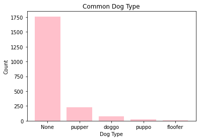

```python
import matplotlib.pyplot as plt
plt.bar(type_name, type_count, color ='pink')
plt.title("Common Dog Type")
plt.xlabel("Dog Type")
plt.ylabel("Count")
```

#### As we can see from the graph, most of the tweets did not provide any information regarding the dog type (about 83.98% of the data). Only 16.02% of the tweet provide the dog type, and 10.97% of them are pupper, 3.53% are doggo, 1.10% are puppo, and 0.42% are floofer.

### 2. the most used twitter source

```python
twitter_arch_copy_1_clean["source"].value_counts()
```

```
Twitter for iPhone     1964
Vine - Make a Scene      91
Twitter Web Client       31
TweetDeck                11
Name: source, dtype: int64
```

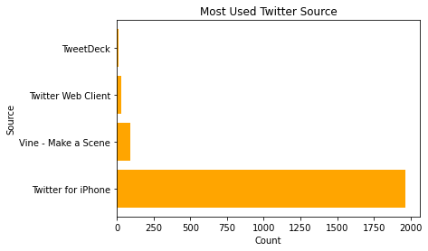

```python
source_name=["Twitter for iPhone" , "Vine - Make a Scene" , "Twitter Web Client" , "TweetDeck"]
source_count=[i for i in twitter_arch_copy_1_clean["source"].value_counts()]
plt.barh(source_name, source_count, color ='orange')
plt.title("Most Used Twitter Source")
plt.xlabel("Count")
plt.ylabel("Source")
```

#### Almost 93.67% of the users used their iPhone as a source for twitter (1964 out of 2097 of the data), and 6.33% of the users used other sources for Twitter.

### 3. the most common dog names

```python
twitter_arch_copy_1_clean["name"].value_counts()
```

```
Unknown           690
Charlie            11
Lucy               11
Oliver             10
Cooper             10
Tucker              9
Penny               9
Sadie               8
Winston             8
Lola                8
Daisy               7
Toby                7
Bailey              6
Oscar               6
Bo                  6
Koda                6
Bella               6
Stanley             6
Jax                 6
Rusty               5
Chester             5
Bentley             5
Milo                5
Louis               5
Dave                5
Scout               5
Buddy               5
Leo                 5
Brody               4
Maggie              4
Jack                4
George              4
Winnie              4
Oakley              4
Jerry               4
Chip                4
very                4
Boomer              4
Sophie              4
Larry               4
```

[output cut: 886 more lines]

```
Cora                1
Huxley              1
Jordy               1
Linus               1
Geno                1
Shiloh              1
Gustav              1
Arlen               1
Burt                1
Lenox               1
Harvey              1
Blanket             1
Jersey              1
Christoper          1
Name: name, dtype: int64
```

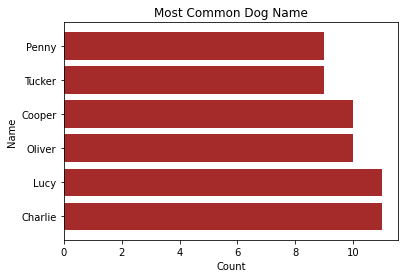

```python
dog_name=[i for i in twitter_arch_copy_1_clean["name"].value_counts().index.tolist()]
dog_count=[i for i in twitter_arch_copy_1_clean["name"].value_counts()]
plt.barh(dog_name[1:7], dog_count[1:7], color ='brown')
plt.title("Most Common Dog Name")
plt.xlabel("Count")
plt.ylabel("Name")
```

#### As can be seen from the horizontal bar graph, which lists the top 6 most popular dog names, Charlie and Lucy are the most popular names given to dogs. Oliver and Cooper came in second, and Tucker and Penny came third.

### 4. the correlation between favorite count and retweet count

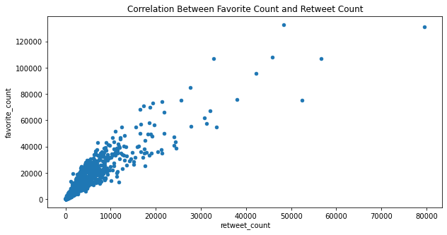

```python
fav=twitter_arch_copy_1_clean[twitter_arch_copy_1_clean["favorite_count"]!=0] #removing unfilled favorite count

fav.plot(x='retweet_count', y='favorite_count', figsize=(10,5), kind="scatter")
plt.title("Correlation Between Favorite Count and Retweet Count")
```

### 5. Count of dogs rates

```python
twitter_arch_copy_1_clean["rating_numerator"].value_counts()
```

```
11      1268
12       486
13       287
14        38
80         1
88         1
144        1
26         1
121        1
44         1
60         1
45         1
50         1
99         1
204        1
1776       1
165        1
27         1
75         1
24         1
84         1
420        1
Name: rating_numerator, dtype: int64
```

```python
rating_numerator=[11,12,13,14,80,88,144,26,121,44,60,45,50,99,204,1776,165,27,75,24,84,420]
rating_numerator_count=[i for i in twitter_arch_copy_1_clean["rating_numerator"].value_counts()]
llist= [[rating_numerator[i],rating_numerator_count[i]] for i in range(22)]
llist
```

```
[[11, 1268],
 [12, 486],
 [13, 287],
 [14, 38],
 [80, 1],
 [88, 1],
 [144, 1],
 [26, 1],
 [121, 1],
 [44, 1],
 [60, 1],
 [45, 1],
 [50, 1],
 [99, 1],
 [204, 1],
 [1776, 1],
 [165, 1],
 [27, 1],
 [75, 1],
 [24, 1],
 [84, 1],
 [420, 1]]
```

```python
# function to sort the values
def Sort(List):
    List.sort(key = lambda l: l[0])
    return List

Sort(llist)
print(llist)
```

```
[[11, 1268], [12, 486], [13, 287], [14, 38], [24, 1], [26, 1], [27, 1], [44, 1], [45, 1], [50, 1], [60, 1], [75, 1], [80, 1], [84, 1], [88, 1], [99, 1], [121, 1], [144, 1], [165, 1], [204, 1], [420, 1], [1776, 1]]
```

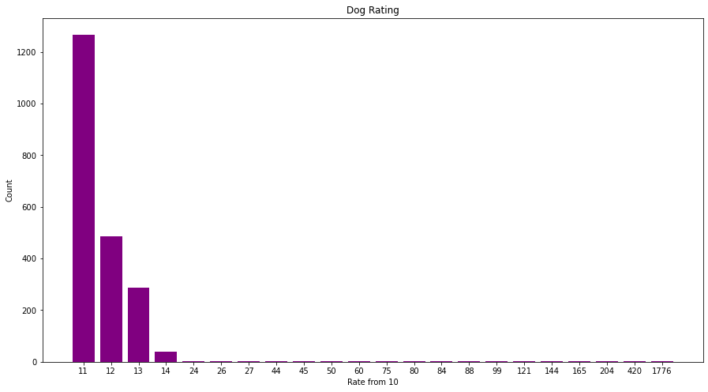

```python
rating_numerator=[str(i[0]) for i in llist ]
rating_numerator_count=[i[1] for i in llist ]
plt.bar(rating_numerator, rating_numerator_count, color ='purple')
plt.gcf().set_size_inches(15, 8)
plt.title("Dog Rating")
plt.xlabel("Rate from 10")
plt.ylabel("Count")
```

#### As we can see, most of the dogs got 11, 12, 13, and 14 out of 10 which is 99.14% of the data (60.47% got 11/10, 23.17% got 12/10, 13.69% got 13/10, and 1.81% got 14/10). The 0.86% of dogs got 15 or more out of 10.